# Home Health

```python
entry_unit_year_percent = patient_visit.groupby(['entry_group'])['patient_id'].value_counts(normalize =True)
#df.groupby(grouping)[column].value_counts(normalize=True).mul(100).rename('Percent').reset_index()
```

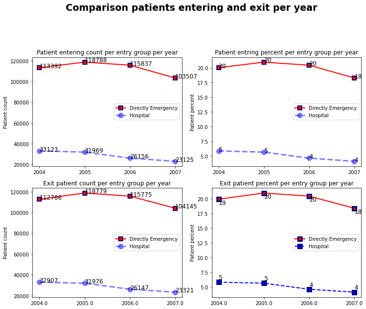

```python
entry_unit_year = patient_visit.groupby(['entry_group','entry_year'], as_index=False)['patient_id'].count()
entry_unit_year['entry_year']=entry_unit_year.entry_year.apply(str)

a = entry_unit_year[entry_unit_year.entry_group==1].reset_index(drop=True)
b = entry_unit_year[entry_unit_year.entry_group==2].reset_index(drop=True)
years = ['2004', '2005', '2006', '2007']

entry_unit_year2 = entry_unit_year
entry_unit_year2['entry_group'] =entry_unit_year.replace(2,'Hospital')
entry_unit_year2['entry_group'] =entry_unit_year.replace(1,'Directly Emergency')
entry_unit_year2['year']=entry_unit_year2.entry_year.apply(str)

entry_year_percent = patient_visit.groupby(['entry_group','entry_year'])['entry_year'].count().rename("Percent_patient").transform(lambda x:x/x.sum()).mul(100).reset_index()
entry_year_percent['entry_year'] = entry_year_percent.entry_year.apply(str)
a_percent = entry_year_percent[entry_year_percent.entry_group==1].reset_index(drop=True)
b_percent = entry_year_percent[entry_year_percent.entry_group==2].reset_index(drop=True)

#EXIT
exit_unit_year = patient_visit.groupby(['entry_group','exit_year'], as_index=False)['patient_id'].count()
exit_unit_year['exit_year']=exit_unit_year.exit_year.apply(str)

a_exit = exit_unit_year[exit_unit_year.entry_group==1].reset_index(drop=True)
b_exit = exit_unit_year[exit_unit_year.entry_group==2].reset_index(drop=True)
years = ['2004', '2005', '2006', '2007']

exit_year_percent = patient_visit.groupby(['entry_group','exit_year'])['exit_year'].count().rename("Percent_patient").transform(lambda x:x/x.sum()).mul(100).reset_index()
exit_year_percent['exit_year'] = exit_year_percent.exit_year.apply(str)
aexit_percent = exit_year_percent[exit_year_percent.entry_group==1].reset_index(drop=True)
bexit_percent = exit_year_percent[exit_year_percent.entry_group==2].reset_index(drop=True)


#PLOTS
plt.figure(figsize=[12, 9])
plt.suptitle('Comparison patients entering and exit per year', y=1.05, fontsize=19, fontweight='bold')

#ENTRY PLOT
plt.subplot(2,2,1)
plt.plot(a.entry_year, a.patient_id, marker='s', c='r', ls='-', lw=2, ms=8, mew=2, mec='navy');
plt.plot(b.entry_year, b.patient_id, marker = 'o', c = 'b', ls='--', lw=3, ms=10, alpha=0.5);
#plt.xlabel('Year');
plt.ylabel('Patient count');
plt.title("Patient entering count per entry group per year");
plt.legend(['Directly Emergency', 'Hospital']);
for i in range(len(a)):
    plt.text(a.entry_year[i],a.patient_id[i]-0.7, int(a.patient_id[i]),size=12);
for i in range(len(b)):
    plt.text(b.entry_year[i],b.patient_id[i] + 0.7, int(b.patient_id[i]),size=12);

plt.subplot(2,2,2)
plt.legend(['Directly Emergency', 'Hospital']);
plt.plot(a_percent.entry_year, a_percent.Percent_patient,marker='s', c='r', ls='-', lw=2, ms=8, mew=2, mec='navy');
plt.plot(b_percent.entry_year, b_percent.Percent_patient,marker = 'o', c = 'b', ls='--', lw=3, ms=10, alpha=0.5);
#plt.xlabel('Year');
plt.ylabel('Patient percent');
plt.title("Patient entring percent per entry group per year");
plt.legend(['Directly Emergency', 'Hospital']);
for i in range(len(a_percent)):
    plt.text(a_percent.entry_year[i],a_percent.Percent_patient[i], int(a_percent.Percent_patient[i]),size=12);
for i in range(len(b_percent)):
    plt.text(b_percent.entry_year[i],b_percent.Percent_patient[i], int(b_percent.Percent_patient[i]),size=12);


#Exit plot
plt.subplot(2,2,3)
plt.plot(a_exit.exit_year, a_exit.patient_id, marker='s', c='r', ls='-', lw=2, ms=8, mew=2, mec='navy');
plt.plot(b_exit.exit_year, b_exit.patient_id, marker = 'o', c = 'b', ls='--', lw=3, ms=10, alpha=0.5);
#plt.xlabel('Year');
plt.ylabel('Patient count');
plt.title("Exit patient count per entry group per year");
plt.legend(['Directly Emergency', 'Hospital']);

for index in range(len(a_exit.exit_year)):
    plt.text(a_exit.exit_year[index],a_exit.patient_id[index], int(a_exit.patient_id[index]),size=12);

for i in range(len(b_exit.exit_year)):
    plt.text(b_exit.exit_year[i],b_exit.patient_id[i], int(b_exit.patient_id[i]),size=12);

plt.subplot(2,2,4)
plt.plot(aexit_percent.exit_year, aexit_percent.Percent_patient, marker='s', c='r', ls='-', lw=2, ms=8, mew=3, mec='navy');
plt.plot(bexit_percent.exit_year, bexit_percent.Percent_patient, marker='s', c='b', ls='--', lw=2, ms=8, mew=3, mec='navy');
#plt.xlabel('Year');
plt.ylabel('Patient percent');
plt.title("Exit patient percent per entry group per year");
plt.legend(["Directly Emergency", "Hospital"]);
for index in range(len(aexit_percent.exit_year)):
  plt.text(aexit_percent.exit_year[index],aexit_percent.Percent_patient[index]-0.9, int(aexit_percent.Percent_patient[index]), size=12)

for index in range(len(bexit_percent.exit_year)):
  plt.text(bexit_percent.exit_year[index],bexit_percent.Percent_patient[index]+0.5, int(bexit_percent.Percent_patient[index]), size=12)
```

- Patients entering directly to emergency are more than patients entering hospital across all years
- Patients who entered directly to emergency are also exiting hospital in larger number across all years
- Overall patient entering hospital and exiting reduced from 2004 to 2007
- Overall patient entering emergency directly increased from 2004 to 2005 and then on reduced.

```python
#LOS per entry_group/yr, per outcome/yr, per  WORK ON THIS
patient_visit['LOS_days'] = (patient_visit.hospitalization_dur_hours) + (patient_visit.ED_dur_hours)
patient_visit['LOS_days'].mean()
```

```
15.545710615182621
```

- Mean LOS is 15.54 hours